# Troubleshooting PGSC_CALC

Peter Fiorica

2024-10-20

# Introduction

I am currently working with `pgcs_calc` to standardize my calculation of ~ 30 PGS. The issue is two fold:

1. PCA with 1000G + HGDP is disastrous and appears as though PC was calculated separately for the reference and target (Pathways) populations and then merged. This appears to be the case with the `oadp` option and `sp` for PC projection.
2. PGS Matchingness/Missiness: I have access to only a limited bit of data from Haiyang’s original pipeline, but I have the matching % for the SBP and T2D PGS. It looks like I have ~.3% fewer matching SNPs in my analysis with PGSC compared to his pipeline. For diabetes, `99.92%` were matched in Haiyang’s analysis compared to `99.70%` in mine.

# 1. Ancestry Analysis

Within the `~/work/ancestry/intersected/` directory, there are 22 files for 22 chromosomes that include those that match between the reference and target population. Let’s take a look at this.

```r
chr_22_matching <- fread("/projects/rpci/songyao/pnfioric/pgs_calc/work/ancestry/intersected/pathways_22_matched.txt.gz")

head(chr_22_matching)
```

```
##      CHR:POS:A0:A1          ID_REF REF_REF IS_INDEL STRANDAMB IS_MA_REF
## 1: 22:16059387:C:T 22:16059387:C:T       C    FALSE     FALSE     FALSE
## 2: 22:16115695:A:G 22:16115695:G:A       G    FALSE     FALSE     FALSE
## 3: 22:16140496:A:G 22:16140496:G:A       G    FALSE     FALSE     FALSE
## 4: 22:16140817:C:T 22:16140817:T:C       T    FALSE     FALSE     FALSE
## 5: 22:16141151:C:G 22:16141151:C:G       C    FALSE      TRUE     FALSE
## 6: 22:16152099:C:T 22:16152099:T:C       T    FALSE     FALSE     FALSE
##          ID_TARGET REF_TARGET IS_MA_TARGET         AAF F_MISS_DOSAGE SAME_REF
## 1: 22:16059387:T:C          T        FALSE 0.000880946             0     TRUE
## 2: 22:16115695:A:G          A        FALSE 0.000755097             0     TRUE
## 3: 22:16140496:A:G          A        FALSE 0.000755097             0     TRUE
## 4: 22:16140817:C:T          C        FALSE 0.000251699             0     TRUE
## 5: 22:16141151:G:C          G        FALSE 0.000503398             0     TRUE
## 6: 22:16152099:C:T          C        FALSE 0.000880946             0     TRUE
##    PCA_ELIGIBLE
## 1:         TRUE
## 2:         TRUE
## 3:         TRUE
## 4:         TRUE
## 5:        FALSE
## 6:         TRUE
```

```r
# First, let's see how many are PCA eligible
table(chr_22_matching$PCA_ELIGIBLE)
```

```
##
##  FALSE   TRUE
##  51167 308252
```

```r
ref_pcs <- fread("/projects/rpci/songyao/pnfioric/pgs_calc/old_work_hgdp/ancestry/fraposa/pca/GRCh37_reference_extracted.pcs", header = T)
targ_pcs <- fread("/projects/rpci/songyao/pnfioric/pgs_calc/old_work_hgdp/ancestry/fraposa/project/GRCh37_pathways_oriented_pathways_splitfamaa.pcs")
```

The majority of these SNPs (~6/7) are PCA eligible.

# 2. SNPs in PGS2308

```r
summary <- fread("/projects/rpci/songyao/pnfioric/pgs_calc/results/pathways/match/pathways_log.csv")

excluded_snps<- summary %>% filter(exclude==TRUE)
unmatched_snps<- summary %>% filter(match_status == "unmatched")

table(summary$match_status)
```

```
##
##  excluded   matched  not_best unmatched
##      2940     45654      2841      2615
```

#### Unmatched SNPs

When we look at the unmatched SNPs, we have a multi-allelic situation for the first SNP I look up:

```
1       1:3103312:A:G   0       3103312 G       A
1       1:3103312:T:G   0       3103312 G       T
```

# Running without Ancestry

I decided to run this without ancestry, and it worked fine. >99.92% of SNPs match.

```
nextflow run pgscatalog/pgsc_calc -profile singularity --input \
    pathways_samplesheet.csv --target_build GRCh37 --keep_ambiguous FALSE --pgs_id \
    PGS002308
```

After this, I wanted to see if rare variants might be contributing to the issue. This did not fix the issue either (below).

```
./nextflow run pgscatalog/pgsc_calc \
    -profile singularity \
    --input pathways_samplesheet.csv --target_build GRCh37 --pgs_id PGS002308  \
    --run_ancestry pgsc_HGDP+1kGP_v1.tar.zst  --maf_ref 0.01 --only_projection --resume
```

#### Exploring Reference Data More

```r
ref_bim <- fread("/vscratch/grp-songyao/pnfioric/pruned_refs.bim")
table(ref_bim$V2 %in% summary$ID) #There are limited SNPs from the pruned HGDP SNPs that intersect PGS model.
```

[output not shown]

# Exploring the Merging Process and genotype prep.

I decided to manually merge the genotypes in plink, run PCA, and plot the results. See below.

```
cd /projects/rpci/songyao/pnfioric/pgs_calc/work/ancestry/filter

plink2 --pfile GRCh37_reference --make-bed --out testfile_ref

plink2 --pfile ../thinned_intersections/GRCh37_pathways_ALL_extracted  --make-bed --out test_target_pw

plink --bfile testfile_ref --bmerge test_target_pw  --make-bed --out test_merge

plink --bfile test_merge --geno 0.1 --make-bed --out test_merge_geno_filter

plink --bfile test_merge_geno_filter --pca --out merged_pca
```

I also added and removed missingness filters to see how this would impact the PCA. It impacted it slightly, but not in the rotation we would like.

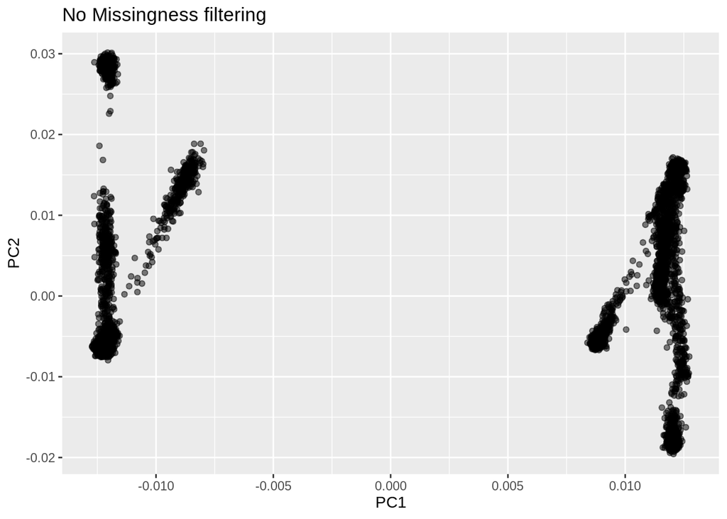

```r
pca_no_filt <- fread("/projects/rpci/songyao/pnfioric/pgs_calc/old_work_hgdp/ancestry/filter/combined_pva.eigenvec")
pca_geno <- fread("/projects/rpci/songyao/pnfioric/pgs_calc/old_work_hgdp/ancestry/filter/merged_pca.eigenvec")

ggplot(pca_no_filt, aes(x=V3, y= V4))+
  geom_point(alpha=0.5)+ xlab("PC1")+ ylab("PC2")+ ggtitle("No Missingness filtering")
```

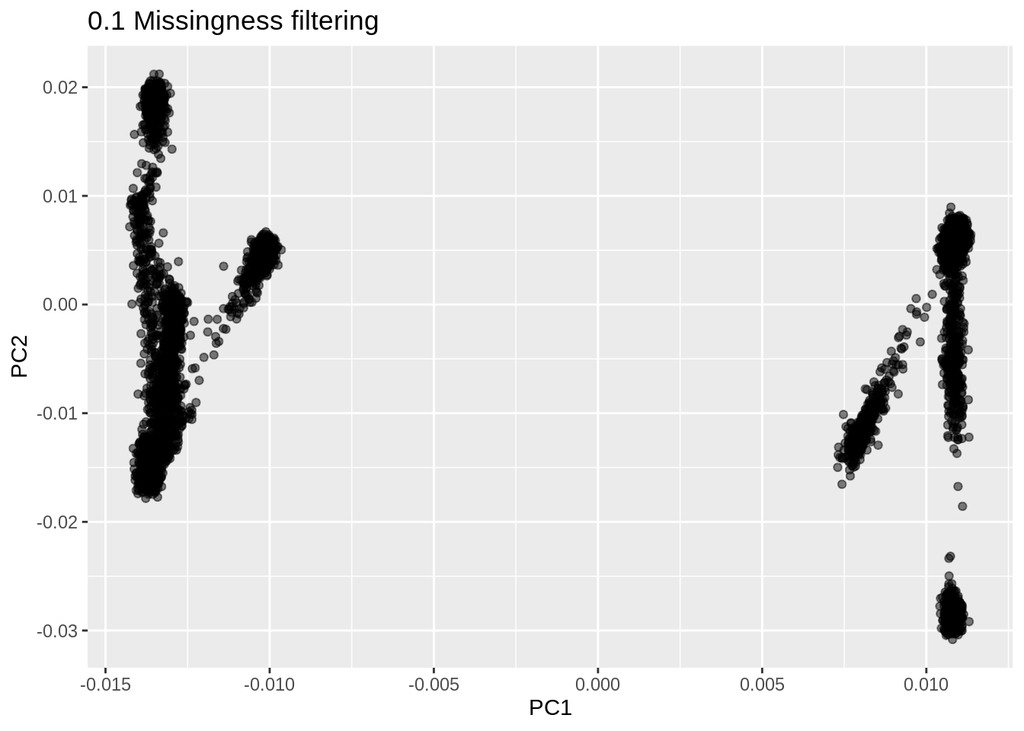

```r
ggplot(pca_geno, aes(x=V3, y= V4))+
  geom_point(alpha=0.5)+ xlab("PC1")+ ylab("PC2")+ ggtitle("0.1 Missingness filtering")
```

We can see from these plots that we still have this brutal mirrored/ reflect PCA. I think this has to be related to the ways the alleles are recorded in the genotype for Pathways.

# Exploring Allele Flipping & Alignment

I will be using reference information from [Wang Lab wiki](https://wanggroup.org/compbio_tutorial/allele_qc.html). For every SNP in our merge there are three possible major possible issues that we can have to navigate:

1. Major/Minor Allele flipping
2. Strand Flipping
3. Strand flipping with complimentary alleles.

### Manipulating 1kgp + HGDP data:

The hg19/gr37 genotypes frorm 1kgp/1000G are extracted from the zipped file for pgsc_calc here: `/projects/rpci/songyao/pnfioric/pgs_calc/work/ancestry/ref_extracted/` This includes all 23M SNPs that intersect with Pathways. The `pw_bim` object includes only those SNPs that pass filters for PCA and intersect with HGDP by position.

The issue is that for a substantial proportion of the SNPs, the ID is mislabeled with ALT/REF alleles flipped.

```r
hgdp_bim<- fread("/projects/rpci/songyao/pnfioric/pgs_calc/old_work_hgdp/ancestry/filter/testfile_ref.bim", header = F)
pw_bim <- fread("/projects/rpci/songyao/pnfioric/pgs_calc/old_work_hgdp/ancestry/filter/test_target_pw.bim", header=F)

hgdp_filt <- hgdp_bim %>%
  inner_join(pw_bim, by = c("V1", "V4"))

hgdp_fixed <- hgdp_filt %>%
  mutate(new_pw_id = case_when(
    V5.x == V5.y ~ V2.y,      # If V5.x matches V5.y, assign V2.y to new_pw_id
    V5.x == V6.y ~ V2.x,      # If V5.x matches V6.y, assign V2.x to new_pw_id
    TRUE ~ V2.y               # Otherwise, keep it as V2.y
  ))

update_snp_list<-hgdp_fixed %>% select(V2.y, new_pw_id) %>%
  filter(duplicated(new_pw_id)==FALSE) %>%
  filter(duplicated(V2.y)==FALSE)
fwrite(update_snp_list,"/projects/rpci/songyao/pnfioric/pgs_calc/work/ancestry/filter/update_list.txt", col.names = F, sep= "\t", quote = F, row.names = F)
```

In the chunk above, I generated a list of SNPs that intersect with mismatching IDs because of allele flips. Below, I update the list of ID names and remerge.

```
plink --bfile testfile_ref --bmerge new_names_pw  --make-bed --out test_merge

plink --bfile test_merge --geno 0.1 --make-bed --out test_merge_geno_filter

plink --bfile test_merge_geno_filter --pca --out merged_pca_updated
```

This did not fix the PCA as shown below. I also decided to flip the signed of PC1 and PC2 for the pathways group. We still see a substantial shift to the PCA plot.

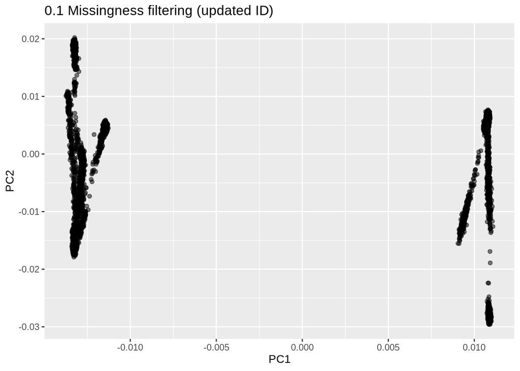

```r
#pca_no_filt <- fread("/projects/rpci/songyao/pnfioric/pgs_calc/work/ancestry/filter/merged_pca_updated.eigenvec")
pca_geno2 <- fread("/projects/rpci/songyao/pnfioric/pgs_calc/old_work_hgdp/ancestry/filter/merged_pca_updated.eigenvec")

ggplot(pca_geno2, aes(x=V3, y= V4))+
  geom_point(alpha=0.5)+ xlab("PC1")+ ylab("PC2")+ ggtitle("0.1 Missingness filtering (updated ID)")
```

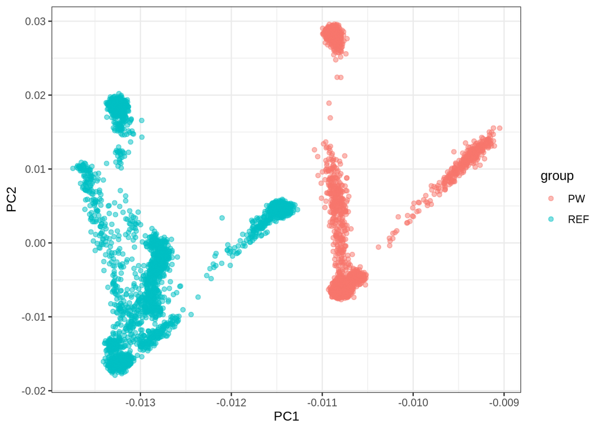

```r
pca_geno2 <- pca_geno2 %>%
  mutate(group = ifelse(row_number() <= 3973, "PW", "REF")) %>%
  mutate(PC1= if_else(group=="PW", V3*-1, V3)) %>%
  mutate(PC2= if_else(group=="PW", V4*-1, V4))

ggplot(pca_geno2, aes(x=PC1, y = PC2, color = group))+
  geom_point(alpha =0.5)+theme_bw()
```

I read that this inverted PC direction may result from palindromic SNPs where the alleles are A-T or G-C. Strand flips for the SNPs cannot be properly identified and corrected. When we check for these SNPs in the intersection, none are present.

#### Checking for palindromic snps

```r
hgdp_fixed <- hgdp_fixed %>%
  mutate(is_palindromic = case_when(
    (V5.x == "A" & V6.x == "T") | (V5.x == "T" & V6.x == "A") ~ TRUE,  # Check if A ↔ T
    (V5.x == "C" & V6.x == "G") | (V5.x == "G" & V6.x == "C") ~ TRUE,  # Check if C ↔ G
    TRUE ~ FALSE  # If neither condition is met, return FALSE
  ))

table(hgdp_fixed$is_palindromic)
```

```
##
## FALSE
## 52341
```

There are no palindromic SNPs in his data. Someone ran into a similar issue in the past in this [thread](https://github.com/meyer-lab-cshl/plinkQC/issues/25).

#### Checking allele frequencies.

```
plink --bfile testfile_ref --freq --out ref_freq

plink --bfile new_names_pw --freq --out pw_freq
```

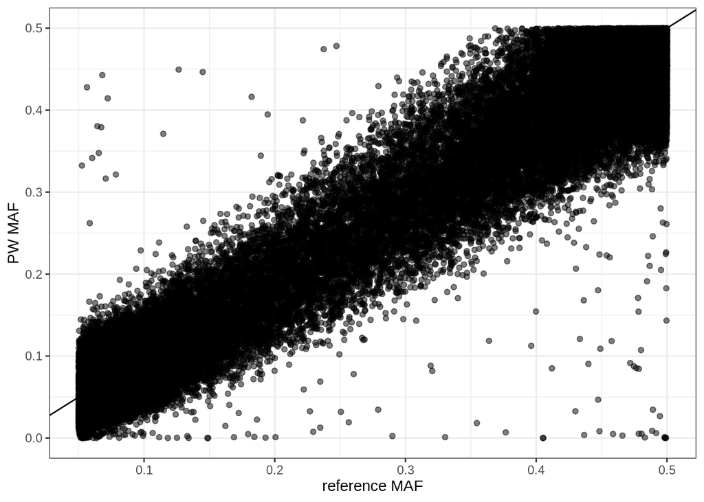

```r
ref_freq<-fread("/projects/rpci/songyao/pnfioric/pgs_calc/old_work_hgdp/ancestry/filter/ref_freq.frq")
pw_freq <-fread("/projects/rpci/songyao/pnfioric/pgs_calc/old_work_hgdp/ancestry/filter/pw_freq.frq")

total_freq <- left_join(ref_freq, pw_freq, by = "SNP")

ggplot(total_freq, aes(x=MAF.x, y= MAF.y))+
  geom_point(alpha = 0.5)+
  geom_abline(slope = 1)+ xlab("reference MAF")+ylab("PW MAF")+theme_bw()
```

# Beginning with genotypes

I recently re-tried pgsc_calc with only 1kGP. It gave me the same issue with the PCA.

I think the issue is related to the .gds to bfile conversion.